## Yay we’ve started!

If you have not ever used GitHub, you will first need to go in and create an account. Look at the guidlines on Jenny Bryant’s Happy Git with R website: https://happygitwithr.com/github-acct.html

Create your git account and make sure you write down your username and password.

Now in github.com, search for the repository here: https://github.com/joan-combs-durso/SpringWorkshop and havd it ready. It’s okay to go ahead and double click on the HTML file called intro-r.html and follow along.

## Introduction

Your 100 level StatSci course this semester will march you through a thorough introduction to using R for statistical science and data science purposes, as well as for many other practical applications. You should already be familiar with the environment you are going to use for your course, whether it is RStudio in the Cloud, a Docker container, or software installed on your own computer. Your instructor should have given you that information and you should be ready to use it. The materials here are a compilation of advice and instructions from your professors Curry Hilton, Victoria Ellison, Yue Jiang, Shawn Santo, Bob Eisinger, and especially Maria Tackett, Mine Cetinkaya-Rundel, and TAs including Becky Tang, Jennifer Wilson, Frances Hu, and many helpful resources.

Here are some key ideas:

If you are in the habit of saying you are not a coder, that stops here.

R is an open source programming language for statistical computing (http://cran-r-project.org).

RStudio is the IDE or Interactive Development Environment we use to work in R. RStudio is available open source, but their company also provides some cloud-based servers for working in their environment, known as RStudio in the Cloud.

## RStudio

Your RStudio window generally has four panels. This is customizable so you might have changed it already. You can also drag the borders to resize each portion.

– Source: Where R markdown files are produced and saved

– Console: Where live R code is run; cannot be saved

– Environment: Where R objects live and are stored

– Utility: Where directories, plots, packages, and help can be found

Your R Markdown file (this document) is in the upper left panel. (Note that the workshop facilitators walked you through getting that file into your RStudio environment from github)

The panel in the upper right contains your *workspace* as well as a history of the commands that you’ve previously entered.

Any plots that you generate will show up in the panel in the lower right corner. This is also where you can browse your files, access help, manage packages, etc.

## R Packages

R is an open-source programming language, meaning that users can contribute packages that make our lives easier, and we can use them for free. For this lab, and many others in the future, we will use the following R packages:

- `statsr`: for data files and functions used in this course
- `dplyr`: for data wrangling
- `ggplot2`: for data visualization
- `usethis`: for workflow automation (and eventually, to help write your own packages!)

```r
#library(dplyr)
#library(ggplot2)
#library(statsr)
#library(usethis)
```

Next, you need to load the packages in your working environment. We do this with the `library` function. Note that you only need to **install** packages once, but you need to **load** them each time you relaunch RStudio.

```r
library(dplyr)
library(ggplot2)
library(statsr)
library(usethis)
```

To do so, you can

- click on the green arrow at the top of the code chunk in the R Markdown (Rmd) file, or
- highlight these lines, and hit the **Run** button on the upper right corner of the pane, or
- type the code in the console.

Going forward you will be asked to load any relevant packages at the beginning of each lab.

## Git and Github

You will use GitHub to obtain the RMarkdown or .Rmd file for this workshop. If you already have a GitHub account, great! If not, take a minute to start one. But first, some user name advice…

Jenny Bryan is an RStudio software engineer who wrote ‘Happy Git and Github for the useR’. She will be a keynote speaker at the RStudio Conference later this month, which you’ll hear more about.  
Meanwhile, here is her page of advice on creating a free Github account and choosing a user name that works. https://happygitwithr.com/github-acct.html Register your free account.  
You’ll have to confirm the request in email.

Now the workshop facilitators will help you fork the repository that contains the software you need.

Configure git.

You will use the use_git_config() function from the usethis package.

Type the following lines of code in the console in RStudio filling in your name and email address.

The email address is the one tied to your GitHub account.

```r
library(usethis)
use_git_config(user.name = "GitHub username", user.email="your email")
```

For example, Joan’s would be

library(usethis) use_git_config(user.name=“joan-combs-durso”, user.email="joan.durso@duke.edu")

Now your facilitators will help you get started with forking the package.

## Dataset Diamonds can be found in the ggplot2 package!

We are going to use a dataset called ‘diamonds’. To get you started, run the following command to load the data and to inspect the first ten rows of the file.

```r
data(diamonds)
#That command loaded the file.  The next one shows you the first ten rows.
diamonds
```

```
## # A tibble: 53,940 x 10
##    carat cut       color clarity depth table price     x     y     z
##    <dbl> <ord>     <ord> <ord>   <dbl> <dbl> <int> <dbl> <dbl> <dbl>
##  1 0.23  Ideal     E     SI2      61.5    55   326  3.95  3.98  2.43
##  2 0.21  Premium   E     SI1      59.8    61   326  3.89  3.84  2.31
##  3 0.23  Good      E     VS1      56.9    65   327  4.05  4.07  2.31
##  4 0.290 Premium   I     VS2      62.4    58   334  4.2   4.23  2.63
##  5 0.31  Good      J     SI2      63.3    58   335  4.34  4.35  2.75
##  6 0.24  Very Good J     VVS2     62.8    57   336  3.94  3.96  2.48
##  7 0.24  Very Good I     VVS1     62.3    57   336  3.95  3.98  2.47
##  8 0.26  Very Good H     SI1      61.9    55   337  4.07  4.11  2.53
##  9 0.22  Fair      E     VS2      65.1    61   337  3.87  3.78  2.49
## 10 0.23  Very Good H     VS1      59.4    61   338  4     4.05  2.39
## # … with 53,930 more rows
```

To do so, once again, you can

- click on the green arrow at the top of the code chunk in the R Markdown (Rmd) file, or
- put your cursor on this line, and hit the **Run** button on the upper right corner of the pane, or
- type the code in the console.

This command instructs R to load some data. You should see that the workspace area in the upper righthand corner of the RStudio window now lists a data set called `diamonds` that has 53940 observations on 10 variables. As you interact with R, you will create a series of objects. Sometimes you load them as we have done here, and sometimes you create them yourself as the byproduct of a computation or some analysis you have performed.

```r
diamonds
```

```
## # A tibble: 53,940 x 10
##    carat cut       color clarity depth table price     x     y     z
##    <dbl> <ord>     <ord> <ord>   <dbl> <dbl> <int> <dbl> <dbl> <dbl>
##  1 0.23  Ideal     E     SI2      61.5    55   326  3.95  3.98  2.43
##  2 0.21  Premium   E     SI1      59.8    61   326  3.89  3.84  2.31
##  3 0.23  Good      E     VS1      56.9    65   327  4.05  4.07  2.31
##  4 0.290 Premium   I     VS2      62.4    58   334  4.2   4.23  2.63
##  5 0.31  Good      J     SI2      63.3    58   335  4.34  4.35  2.75
##  6 0.24  Very Good J     VVS2     62.8    57   336  3.94  3.96  2.48
##  7 0.24  Very Good I     VVS1     62.3    57   336  3.95  3.98  2.47
##  8 0.26  Very Good H     SI1      61.9    55   337  4.07  4.11  2.53
##  9 0.22  Fair      E     VS2      65.1    61   337  3.87  3.78  2.49
## 10 0.23  Very Good H     VS1      59.4    61   338  4     4.05  2.39
## # … with 53,930 more rows
```

However printing the whole dataset in the console is not that useful. One advantage of RStudio is that it comes with a built-in data viewer. Click on the name `diamonds` in the *Environment* pane (upper right window) that lists the objects in your workspace. This will bring up an alternative display of the data set in the *Data Viewer* (upper left window). You can close the data viewer by clicking on the *x* in the upper lefthand corner.

Note that the row numbers in the first column are not part of the ‘diamonds’ data. R adds them as part of its printout to help you make visual comparisons. You can think of them as the index that you see on the left side of a spreadsheet. In fact, the comparison to a spreadsheet will generally be helpful. R has stored the ‘diamonds’ data in a kind of spreadsheet or table called a *data frame*.

You can see the dimensions of this data frame by typing:

```r
dim(diamonds)
```

```
## [1] 53940    10
```

This command should output `[1] 53940 10`, indicating that there are 53940 rows or observations and 10 columns or fieldnames. columns (we’ll get to what the `[1]` means in a bit), just as it says next to the object in your workspace. You can see the names of these columns (or variables) by typing:

```r
names(diamonds)
```

```
##  [1] "carat"   "cut"     "color"   "clarity" "depth"   "table"   "price"
##  [8] "x"       "y"       "z"
```

How many variables are included in this data set?

- 2
- 9
- 10
- 82
- 53940

What are some of the values for ‘cut" included in this dataset? Hint: Take a look at the ’cut’ variable in the Data Viewer to answer this question.

You should see that the data frame contains the columns `price`, `carat`, and `cut`. At this point, you might notice that many of the commands in R look a lot like functions from math class; that is, invoking R commands means supplying a function with some number of arguments. The `dim` and `names` commands, for example, each took a single argument, the name of a data frame.

**Tip:** If you use the up and down arrow keys, you can scroll through your previous commands, your so-called command history. You can also access it by clicking on the history tab in the upper right panel. This will save you a lot of typing in the future.

### R Markdown

So far we asked you to type your commands in the console. The console is a great place for playing around with some code, however it is not a good place for documenting your work. Working in the console exclusively makes it difficult to document your work as you go, and reproduce it later.

### Some Exploration

Let’s start to examine the data a little more closely. To find out more about this dataset, you could use some help. Tyr typing the name of the dataset with a ‘?’ in front of it.

```r
?diamonds
```

You should see the documentation on the dataset in the Help window. Try out the other tabs there briefly.  
We can access the data in a single column of a data frame separately using a command like

```r
diamonds$clarity[1:100]
```

```
##   [1] SI2  SI1  VS1  VS2  SI2  VVS2 VVS1 SI1  VS2  VS1  SI1  VS1  SI1  SI2  SI2
##  [16] I1   SI2  SI1  SI1  SI1  SI2  VS2  VS1  SI1  SI1  VVS2 VS1  VS2  VS2  VS1
##  [31] VS1  VS1  VS1  VS1  VS1  VS1  VS1  SI1  VS2  SI2  SI2  SI1  VS2  VS1  SI2
##  [46] SI1  SI2  SI2  VS2  SI2  SI1  VS1  SI1  VS2  VS2  SI2  SI2  SI1  SI1  SI1
##  [61] VS1  SI1  SI1  SI1  SI2  VVS2 VVS1 SI1  SI1  VVS1 VVS1 SI1  SI1  SI1  SI1
##  [76] VVS2 VVS2 VVS2 VVS2 VVS1 VVS1 VVS1 VVS2 SI2  VVS1 VVS1 VVS1 VVS1 VVS2 SI1
##  [91] SI1  SI2  VS2  VS2  SI2  VS2  VS1  SI2  SI1  SI1
## Levels: I1 < SI2 < SI1 < VS2 < VS1 < VVS2 < VVS1 < IF
```

What command would you use to extract just the data on diamond length?

- `diamonds$x`
- `x`
- `diamonds[x]`
- `$x`

```r
# type your code for the Question 2 here, and Knit
diamonds$x[1:10]
```

```
##  [1] 3.95 3.89 4.05 4.20 4.34 3.94 3.95 4.07 3.87 4.00
```

Notice that the way R has printed these data is different. When we looked at the complete data frame, we could have seen 53940 rows, one on each line of the display. These data are no longer structured in a table with other variables, so they are displayed one right after another. Objects that print out in this way are called vectors; they represent a set of numbers. R has added numbers in [brackets] along the left side of the printout to indicate locations within the vector. For example, 3.95 follows [1], indicating that 3.95 is the first entry in the vector. And if [801] starts a line, then that would mean the first number on that line would represent the 801st entry in the vector.

R has some powerful functions for making graphics. We can create a simple plot of the price of diamonds by their weight measured in carats with the command

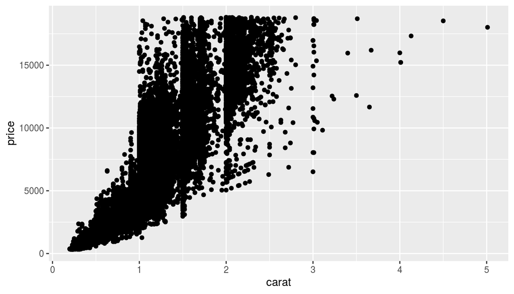

```r
ggplot(data = diamonds, aes(x = carat, y = price)) +
  geom_point()
```

Before we review the code for this plot, let’s summarize the trends we see in the data.

Which of the following best describes the relationship between price and diamond weight on stones included in this dataset?

- There are so many dots it is hard to see a trend!
- Price and diamond weight in carats are positively related.
- The heavier the rock, the pricier it is!
- Who wants to buy diamonds anyway?
- This is a really ugly plot; there must be more to learn!

Back to the code… We use the `ggplot()` function to build plots. If you run the plotting code in your console, you should see the plot appear under the *Plots* tab of the lower right panel of RStudio. Notice that the command above again looks like a function, this time with arguments separated by commas.

- The first argument is always the dataset.
- Next, we provide the variables from the dataset to be assigned to `aes`thetic elements of the plot, e.g. the x and the y axes.
- Finally, we use another layer, separated by a `+` to specify the `geom`etric object for the plot. Since we want to scatterplot, we use `geom_point`.

You might wonder how you are supposed to know the syntax for the `ggplot` function. Thankfully, R documents all of its functions extensively. To read what a function does and learn the arguments that are available to you, just type in a question mark followed by the name of the function that you’re interested in. Try the following in your console:

```r
?ggplot
```

Notice that the help file replaces the plot in the lower right panel. You can toggle between plots and help files using the tabs at the top of that panel.

More extensive help for plotting with the `ggplot2` package can be found at http://docs.ggplot2.org/current/. The best (and easiest) way to learn the syntax is to take a look at the sample plots provided on that page, and modify the code bit by bit until you get achieve the plot you want.

### R as a big calculator

Now, suppose we want to plot the total dimensions of each of the diamonds. To compute this, we could use the fact that R is really just a big calculator. We can type in mathematical expressions like

```r
3.95 + 3.98 + 2.43
```

```
## [1] 10.36
```

to get the value for that first one. We could repeat this once for each stone, but there is a faster way. If we add the vector for each, R will compute all sums simultaneously.

```r
sum_xyz <- diamonds$x + diamonds$y + diamonds$z
sum_xyz[1:10]
```

```
##  [1] 10.36 10.04 10.43 11.06 11.44 10.38 10.40 10.71 10.14 10.44
```

### Adding a new variable to the data frame

We’ll be using this new vector to generate some plots, so we’ll want to save it as a permanent column in our data frame.

```r
diamonds <- diamonds %>%
  mutate(total = x + y + z)
```

What in the world is going on here? The `%>%` operator is called the **piping** operator. Basically, it takes the output of the current line and pipes it into the following line of code.

*“Take the `diamonds` dataset and **pipe** it into the `mutate` function. Using this mutate a new variable called `total` that is the sum of the dimensions called `x` and `y` and ‘z’ for each stone. Then assign this new resulting dataset to the object called `diamonds`, i.e. overwrite the old `diamonds` dataset with the new one containing the new variable.”*

This is essentially equivalent to going through each row and adding up the dimensions for each stone and recording that value in a new column called total.

**Where is the new variable?** When you make changes to variables in your dataset, click on the name of the dataset again to update it in the data viewer.

You’ll see that there is now a new column called `total` that has been tacked on to the data frame. The special symbol `<-` performs an *assignment*, taking the output of one line of code and saving it into an object in your workspace. In this case, you already have an object called `diamondst`, so this command updates that data set with the new mutated column.

We can make a plot comparing diamond table by total dimensions with the following command.

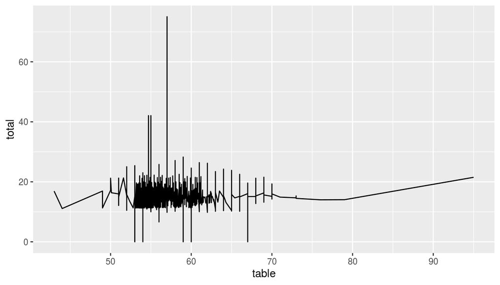

```r
ggplot(data = diamonds, aes(x = table, y = total)) +
  geom_line()
```

Note that using `geom_line()` instead of `geom_point()` results in a line plot instead of a scatter plot. You want both? Just layer them on:

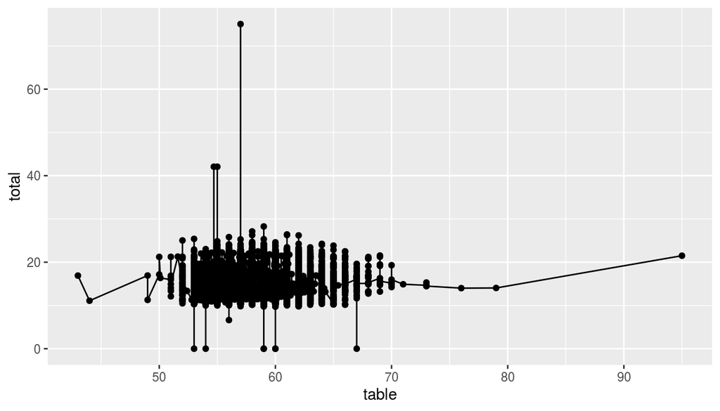

```r
ggplot(data = diamonds, aes(x = table, y = total)) +
  geom_line() +
  geom_point()
```

Eek…it looks like something that is going to crawl off the screen on its six legs! These are some really ugly plots. You can do better!

Think about diamonds…some of them are fairly flat while others are quite pointed. It all depends on the 4 C’s of the stone. There are many resources on the internet to find out how diamonds are valued and what is interesting about them.

Now, with your partner, play with mutate and piping and create a plot of interest to you.

```r
# type your code for the Exercise here, and Knit
```

Finally, in addition to simple mathematical operators like subtraction and division, you can ask R to make logical comparisons like greater than, `>`, less than, `<`, and equality, `==`. For example, we can ask if the x dimension is greater than the y dimension for these stones with the expression

```r
diamonds <- diamonds %>%
  mutate(more_x = x > y)
```

This command add a new variable to the `diamonds` data frame containing the values of either `TRUE` if that stone was longer than its width, or `FALSE` if it was not (the answer may surprise you).

This variable contains different kind of data than we have considered so far. All other columns in the `diamonds` data frame have values that are numerical (carat, table and width) or text (color, cut). Here, we’ve asked R to create *logical* data, data where the values are either `TRUE` or `FALSE`. In general, data analysis will involve many different kinds of data types, and one reason for using R is that it is able to represent and compute with many of them.

We can use just part of the dataset by filtering. Here, we are going to filter on a particular value of cut and color and plot price vs carat.

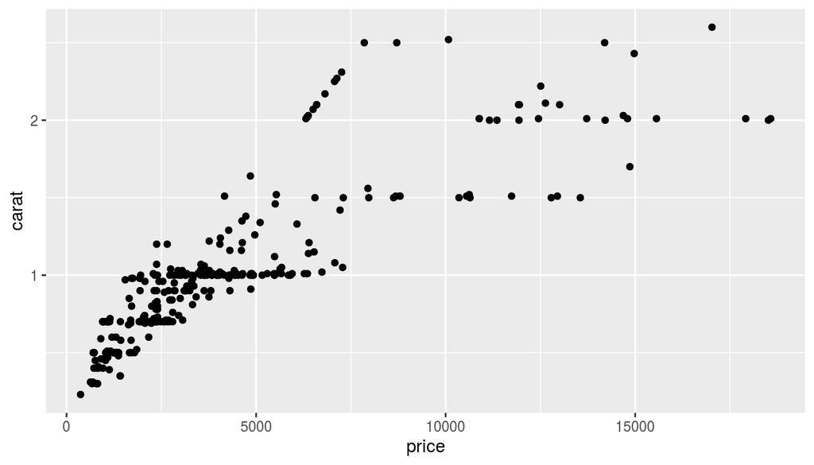

```r
fair_diamonds <- diamonds %>%
  filter(cut == "Fair" & color =="G")
ggplot(data = fair_diamonds, aes(x = price, y = carat)) +
  geom_point()
```

```r
diamonds %>%
  summarise(mean = mean(price), sd = sd(price), median = median(price))
```

```
## # A tibble: 1 x 3
##    mean    sd median
##   <dbl> <dbl>  <dbl>
## 1 3933. 3989.   2401
```

## Resources for learning R and working in RStudio

That was a short introduction to R and RStudio, but your instructors will provide you with more functions and a more complete sense of the language as your course progresses. You might find the following tips and resources helpful.

- Many courses use the Tidyverse while other courses will expect you to learn to work in base R, rather than in the RStudio IDE. In Tidyverse-flavored courses, you will use `dplyr` (for data wrangling) and `ggplot2` (for data visualization) extensively. If you are googling for R code, make sure to also include these package names in your search query. For example, instead of googling “scatterplot in R”, google “scatterplot in R with ggplot2”.

-There is a terrific resource on Medium called Towards Data Science, and you can find good information there, although you may have a limited number of free articles to read. https://towardsdatascience.com/data-science/home

-Do a quick search on “Free books on R” and you will find a huge array of choices.

-Lots of R users post their own guides that you can find by searching. Here’s one from David Romney at Harvard: https://scholar.harvard.edu/dromney/online-resources-learning-r

-The r-statistics blog is very helpful: https://www.r-statistics.com/ In fact, you will find that the R community by its very nature is beginner friendly.

You can attend as much of the RStudio Conference that you want, by joining our RStudio conference livestream watch party on January 29 and 30, right here at Duke. More info here: https://blogs.library.duke.edu/data/2020/01/13/2020-rstudio-conference-livestream-coming-to-duke-libraries/

- The following cheatsheets may come in handy throughout your courses. Note that some of the code on these cheatsheets may be too advanced for your needs now, however the majority of it will become useful as you progress through your statistical science courses.
  - [Data wrangling cheatsheet](http://www.rstudio.com/wp-content/uploads/2015/02/data-wrangling-cheatsheet.pdf)
  - [Data visualization cheatsheet](https://github.com/rstudio/cheatsheets/raw/master/data-visualization-2.1.pdf)
  - [R Markdown](https://github.com/rstudio/cheatsheets/raw/master/rmarkdown-2.0.pdf)

## Troubleshooting

If you run into problems with your RStudio work, start by inspecting the console for error messages. See what it tells you. Then you can try to look up that error message. Sites like Stack Overflow https://stackoverflow.com/questions/tagged/rstudio provide lots of resources and answers to questions people have already asked. You will learn R more quickly if you try to solve problems yourself. We all need help at times.

If you need help with a problem in your labs, please ask your TA or your classmates. Don’t be the person who posts a question to a website like Stack Overflow for which the answers can be readily found on the internet via a simple search. Those kinds of questions will be ignored or will result in heaps of abuse. Some sites are more beginner-friendly than others. Your TAs will have some suggestions for you.

Whatever you do, please don’t post your assigned questions onto paid answer-sharing services. That’s a violation of the Community Standard as well as a very poor way to learn to use R.

Acknowledgements: This is derived from a Statistics with R lab derived from an Open Intro Statistics lab. Thanks to Mine Cetinkaya-Rundel and Maria Tackett for all their help.

This is a derivative of an [OpenIntro](https://www.openintro.org/stat/labs.php) lab, and is released under a [Attribution-NonCommercial-ShareAlike 3.0 United States](https://creativecommons.org/licenses/by-nc-sa/3.0/us/) license.